# Unit 1 Homework

### W203 Statistics for Data Science

Student Name: Brad Andersen

Section Number: W203.4

### Exercises

**1.0:** Load the dataset found in the file, cars.csv.

```r
carsData <- read.csv("cars.csv", header = TRUE)
```

**2.0:** What are the variables in the file?

```r
ls(carsData)
```

1. 'am'

2. 'carb'

3. 'cyl'

4. 'disp'

5. 'drat'

6. 'gear'

7. 'hp'

8. 'mpg'

9. 'qsec'

10. 'vs'

11. 'wt'

**3.0** Find the mean, median, minimum, maximum, 1st quartile and 3rd quartile for the mpg variable.

```r
carsMpg <- carsData[, "mpg"]
summary(carsMpg)
```

```
   Min. 1st Qu.  Median    Mean 3rd Qu.    Max.
  10.40   15.20   18.70   19.49   21.50   33.90
```

**4.0:** Create a histogram of the mpg variable.

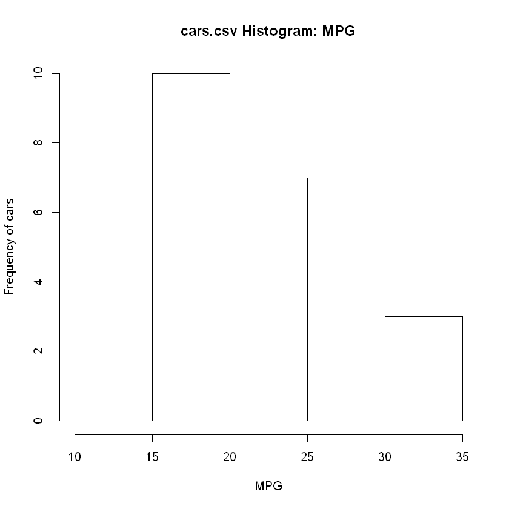

```r
hist(carsMpg, main = "cars.csv Histogram: MPG", xlab = "MPG", ylab = "Frequency of cars")
```

**5.0:** What is the standard deviation of mpg variable?

```r
sd(carsMpg)
```

6.04744574179876

**6.0:** What is the variance of mpg variable?

```r
var(carsMpg)
```

36.5716

**7.0:** What is the relationship of the standard deviation to the variance? Why does the standard deviation and variance of the mpg variable differ?

The **variance** represents how spread out the individual data are from the mean. The **standard deviation** is the square root of the variance.

Both the standard deviation and the variance offer a numeric representation of the spread of data. However, they are represented using different numeric units. The **standard deviation** is expressed using the same units of measurement as the data, while the **variance** is expressed using the square of the units of measurement.

**8.0** How many data points are there for the cyl variable?

```r
carsCyl <- carsData[, "cyl"]
length(carsCyl[!is.na(carsCyl)])
```

23

**9.0** What is the mean of the cyl variable?

```r
mean(carsCyl[!is.na(carsCyl)])
```

6.26086956521739